# Correction des exercices

## Exercice 5.2.4

*Examinez les tableaux rates, storms et population du package EDAWR.*

- Ces tableaux sont-ils des “tableaux rangés” (tidy data) ?
- Si oui, quelles sont les variables représentées ?
- Si non, transformez-les en “tableaux rangés”.

```r
# Installation et mise en mémoire des packages nécessaires
# install.packages("devtools")
# library(devtools)

# install_github("rstudio/EDAWR")
library(EDAWR)
```

Affichage des tableaux :

```r
rates
```

```
## # A tibble: 3,484 x 5
##    country      year cases population  rate
##    <chr>       <int> <dbl>      <int> <dbl>
##  1 Afghanistan  1997   128   19021226  0.07
##  2 Afghanistan  1998  1778   19496836  0.91
##  3 Afghanistan  1999   745   19987071  0.37
##  4 Afghanistan  2000  2666   20595360  1.29
##  5 Afghanistan  2001  4639   21347782  2.17
##  6 Afghanistan  2002  6509   22202806  2.93
##  7 Afghanistan  2003  6528   23116142  2.82
##  8 Afghanistan  2004  8245   24018682  3.43
##  9 Afghanistan  2005  9949   24860855  4
## 10 Afghanistan  2006 12469   25631282  4.86
## # … with 3,474 more rows
```

`rates` est un tableau rangé avec une variable par colonne (pays, année, nombre de cas de tuberculose, population globale, et taux de malades) et une ligne par observation.

```r
storms
```

```
## # A tibble: 6 x 4
##   storm    wind pressure date
##   <chr>   <int>    <int> <date>
## 1 Alberto   110     1007 2000-08-03
## 2 Alex       45     1009 1998-07-27
## 3 Allison    65     1005 1995-06-03
## 4 Ana        40     1013 1997-06-30
## 5 Arlene     50     1010 1999-06-11
## 6 Arthur     45     1010 1996-06-17
```

`storms` est un tableau rangé avec une variable par colonne (nom de la tempête, vitesse du vent en mph, pression en millibars et date à laquelle la plus forte vitesse de vent a été enregistrée) et une ligne par observation.

```r
population
```

```
## # A tibble: 100 x 20
##    country `1995` `1996` `1997` `1998` `1999` `2000` `2001` `2002` `2003`
##    <chr>    <int>  <int>  <int>  <int>  <int>  <int>  <int>  <int>  <int>
##  1 Afghan… 1.76e7 1.84e7 1.90e7 1.95e7 2.00e7 2.06e7 2.13e7 2.22e7 2.31e7
##  2 Algeria 2.93e7 2.98e7 3.03e7 3.08e7 3.13e7 3.17e7 3.22e7 3.26e7 3.30e7
##  3 Angola  1.21e7 1.25e7 1.28e7 1.31e7 1.35e7 1.39e7 1.44e7 1.49e7 1.54e7
##  4 Argent… 3.48e7 3.53e7 3.57e7 3.61e7 3.65e7 3.69e7 3.73e7 3.76e7 3.80e7
##  5 Azerba… 7.77e6 7.85e6 7.92e6 7.98e6 8.05e6 8.12e6 8.20e6 8.28e6 8.37e6
##  6 Bangla… 1.20e8 1.22e8 1.25e8 1.27e8 1.30e8 1.32e8 1.35e8 1.37e8 1.39e8
##  7 Belarus 1.02e7 1.02e7 1.01e7 1.01e7 1.00e7 9.98e6 9.92e6 9.85e6 9.78e6
##  8 Benin   5.99e6 6.18e6 6.36e6 6.55e6 6.74e6 6.95e6 7.17e6 7.41e6 7.67e6
##  9 Bolivi… 7.64e6 7.81e6 7.98e6 8.15e6 8.32e6 8.50e6 8.67e6 8.84e6 9.02e6
## 10 Botswa… 1.58e6 1.62e6 1.66e6 1.69e6 1.72e6 1.76e6 1.78e6 1.81e6 1.83e6
## # … with 90 more rows, and 10 more variables: `2004` <int>, `2005` <int>,
## #   `2006` <int>, `2007` <int>, `2008` <int>, `2009` <int>, `2010` <int>,
## #   `2011` <int>, `2012` <int>, `2013` <int>
```

`population` n’est pas un tableau rangé. Les variables devraient être pays, année et population

```r
gather(population, key = year, value = pop, `1995`:`2013`)
```

```
## # A tibble: 1,900 x 3
##    country                          year        pop
##    <chr>                            <chr>     <int>
##  1 Afghanistan                      1995   17586073
##  2 Algeria                          1995   29315463
##  3 Angola                           1995   12104952
##  4 Argentina                        1995   34833168
##  5 Azerbaijan                       1995    7770806
##  6 Bangladesh                       1995  119869585
##  7 Belarus                          1995   10189075
##  8 Benin                            1995    5985658
##  9 Bolivia (Plurinational State of) 1995    7635362
## 10 Botswana                         1995    1583453
## # … with 1,890 more rows
```

## Exercice 5.3.4

*1. L’objet dauphin est-il “tidy” (autrement dit, s’agit-il de “données rangées”) ? Justifiez.*

```r
# Importation du jeu de données `dauphin` :
library(readxl)
dauphin <- read_excel("dauphin.xls", na = "*", skip = 9)
names(dauphin) <- c("ID", "Sexe", "Statut", "Taille", "Age", "Cd", "Cu", "Hg", "Organe")
dauphin
```

```
## # A tibble: 93 x 9
##    ID        Sexe  Statut Taille   Age     Cd    Cu    Hg Organe
##    <chr>     <chr> <chr>   <dbl> <dbl>  <dbl> <dbl> <dbl> <chr>
##  1 Numéro 1  f     imm       315     3  29.6   3.24 NA    rein
##  2 Numéro 2  f     imm       357     4  55.1   4.42 NA    rein
##  3 Numéro 3  f     pnl       439    34 129.    5.01  9.02 rein
##  4 Numéro 4  f     imm       316     4  71.2   4.33 NA    rein
##  5 Numéro 5  f     l         435    26 192     5.15 NA    rein
##  6 Numéro 6  f     pnl       388     6  NA     4.12  4.53 rein
##  7 Numéro 7  f     mat       410    NA  76     5.1  33.9  foie
##  8 Numéro 8  m     imm       355    NA  74.4   4.72 13.3  foie
##  9 Numéro 9  m     imm       222    NA   0.09  9.5   2.89 foie
## 10 Numéro 10 m     imm       412     9  85.6   5.42 NA    rein
## # … with 83 more rows
```

Oui, `dauphin` est “tidy”. Il contient une variable par colonne, une observation par ligne. La variable ID pourrait toutefois être supprimée.

*2. Produisez le graphique ci-dessous*

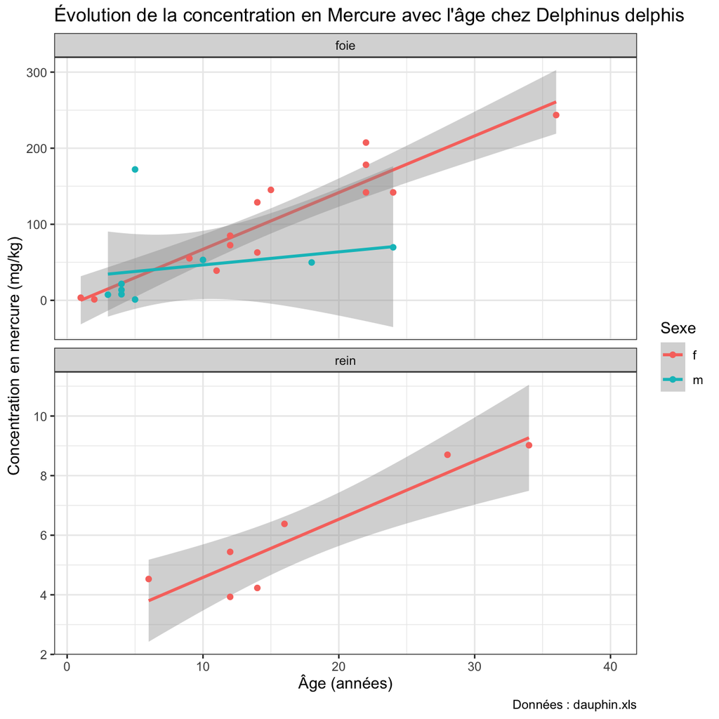

```r
ggplot(dauphin, aes(x = Age, y = Hg, color = Sexe)) +
  geom_smooth(method = "lm") +
  geom_point() +
  facet_wrap(~ Organe, nrow = 2, scales = "free_y") +
  labs(x = "Âge (années)",
       y = "Concentration en mercure (mg/kg)",
       title = "Évolution de la concentration en Mercure avec l'âge chez Delphinus delphis",
       color = "Sexe",
       caption = "Données : dauphin.xls") +
  theme_bw()
```

*3. Importez dans R le jeu de données whoTB.csv. Ce jeu de données contient les cas de tuberculose (TB) rapportés par l’Organisation Mondiale de la Santé (OMS, ou WHO en anglais : World Health Organization). Les cas sont répertoriés par année, pays, âge, sexe, type de tuberculose et méthode de diagnostique. Selon vous, ce jeu de données est-il “rangé” ? Pourquoi ?*

```r
library(readr)
whoTB <- read_csv("whoTB.csv")
whoTB
```

```
## # A tibble: 7,240 x 60
##    country iso2  iso3   year new_sp_m014 new_sp_m1524 new_sp_m2534
##    <chr>   <chr> <chr> <dbl>       <dbl>        <dbl>        <dbl>
##  1 Afghan… AF    AFG    1980          NA           NA           NA
##  2 Afghan… AF    AFG    1981          NA           NA           NA
##  3 Afghan… AF    AFG    1982          NA           NA           NA
##  4 Afghan… AF    AFG    1983          NA           NA           NA
##  5 Afghan… AF    AFG    1984          NA           NA           NA
##  6 Afghan… AF    AFG    1985          NA           NA           NA
##  7 Afghan… AF    AFG    1986          NA           NA           NA
##  8 Afghan… AF    AFG    1987          NA           NA           NA
##  9 Afghan… AF    AFG    1988          NA           NA           NA
## 10 Afghan… AF    AFG    1989          NA           NA           NA
## # … with 7,230 more rows, and 53 more variables: new_sp_m3544 <dbl>,
## #   new_sp_m4554 <dbl>, new_sp_m5564 <dbl>, new_sp_m65 <dbl>,
## #   new_sp_f014 <dbl>, new_sp_f1524 <dbl>, new_sp_f2534 <dbl>,
## #   new_sp_f3544 <dbl>, new_sp_f4554 <dbl>, new_sp_f5564 <dbl>,
## #   new_sp_f65 <dbl>, new_sn_m014 <dbl>, new_sn_m1524 <dbl>,
## #   new_sn_m2534 <dbl>, new_sn_m3544 <dbl>, new_sn_m4554 <dbl>,
## #   new_sn_m5564 <dbl>, new_sn_m65 <dbl>, new_sn_f014 <dbl>,
## #   new_sn_f1524 <dbl>, new_sn_f2534 <dbl>, new_sn_f3544 <dbl>,
## #   new_sn_f4554 <dbl>, new_sn_f5564 <dbl>, new_sn_f65 <dbl>,
## #   new_ep_m014 <dbl>, new_ep_m1524 <dbl>, new_ep_m2534 <dbl>,
## #   new_ep_m3544 <dbl>, new_ep_m4554 <dbl>, new_ep_m5564 <dbl>,
## #   new_ep_m65 <dbl>, new_ep_f014 <dbl>, new_ep_f1524 <dbl>,
## #   new_ep_f2534 <dbl>, new_ep_f3544 <dbl>, new_ep_f4554 <dbl>,
## #   new_ep_f5564 <dbl>, new_ep_f65 <dbl>, new_rel_m014 <dbl>,
## #   new_rel_m1524 <dbl>, new_rel_m2534 <dbl>, new_rel_m3544 <dbl>,
## #   new_rel_m4554 <dbl>, new_rel_m5564 <dbl>, new_rel_m65 <dbl>,
## #   new_rel_f014 <dbl>, new_rel_f1524 <dbl>, new_rel_f2534 <dbl>,
## #   new_rel_f3544 <dbl>, new_rel_f4554 <dbl>, new_rel_f5564 <dbl>,
## #   new_rel_f65 <dbl>
```

Ce jeu de données n’est pas rangé car outre les 4 premières colonnes, toutes les autres contiennent de multiples informations : nouveaux cas ou anciens (ici, ils sont tous nouveaux), type de cas (`sp`, `sn`, `ep` ou `rel`), sexe des patients (`m` ou `f`) et enfin tranches d’âges. Nous devrions donc avoir ces 4 variables supplémentaires, avec pour chaque combinaison possible, le nombre de cas de tuberculose rapportée dans les colonnes.

*4. Si ce jeu de données n’est pas rangé, rangez-le en utilisant les fonctions du packages tidyr que nous avons découvertes dans ce chapitre : gather(), spread(), separate() et unite() (vous n’aurez pas nécessairement besoin d’utiliser ces 4 fonctions, et à l’inverse, certaines devront peut-être être utilisées plusieurs fois).*

On commence donc par rassembler toutes les colonnes en une seule, nommée `composite` et tous les chiffres dans une colonne `cases` :

```r
whoTB %>%
  gather(key = composite, value = cases, `new_sp_m014`:`new_rel_f65`)
```

```
## # A tibble: 405,440 x 6
##    country     iso2  iso3   year composite   cases
##    <chr>       <chr> <chr> <dbl> <chr>       <dbl>
##  1 Afghanistan AF    AFG    1980 new_sp_m014    NA
##  2 Afghanistan AF    AFG    1981 new_sp_m014    NA
##  3 Afghanistan AF    AFG    1982 new_sp_m014    NA
##  4 Afghanistan AF    AFG    1983 new_sp_m014    NA
##  5 Afghanistan AF    AFG    1984 new_sp_m014    NA
##  6 Afghanistan AF    AFG    1985 new_sp_m014    NA
##  7 Afghanistan AF    AFG    1986 new_sp_m014    NA
##  8 Afghanistan AF    AFG    1987 new_sp_m014    NA
##  9 Afghanistan AF    AFG    1988 new_sp_m014    NA
## 10 Afghanistan AF    AFG    1989 new_sp_m014    NA
## # … with 405,430 more rows
```

Puisqu’ils y a beaucoup de données manquantes, on les supprime. Cela nous permet de passer de plus de 400000 lignes à environ 76000

```r
whoTB %>%
  gather(key = composite, value = cases, `new_sp_m014`:`new_rel_f65`, na.rm = TRUE)
```

```
## # A tibble: 76,046 x 6
##    country     iso2  iso3   year composite   cases
##    <chr>       <chr> <chr> <dbl> <chr>       <dbl>
##  1 Afghanistan AF    AFG    1997 new_sp_m014     0
##  2 Afghanistan AF    AFG    1998 new_sp_m014    30
##  3 Afghanistan AF    AFG    1999 new_sp_m014     8
##  4 Afghanistan AF    AFG    2000 new_sp_m014    52
##  5 Afghanistan AF    AFG    2001 new_sp_m014   129
##  6 Afghanistan AF    AFG    2002 new_sp_m014    90
##  7 Afghanistan AF    AFG    2003 new_sp_m014   127
##  8 Afghanistan AF    AFG    2004 new_sp_m014   139
##  9 Afghanistan AF    AFG    2005 new_sp_m014   151
## 10 Afghanistan AF    AFG    2006 new_sp_m014   193
## # … with 76,036 more rows
```

Il nous faut ensuite séparer la colonne composite en plusieurs colonnes. On va se servir des `_` pour isoler `new`, le type de cas, et la combinaison `SexeAge` :

```r
whoTB %>%
  gather(key = composite, value = cases, `new_sp_m014`:`new_rel_f65`, na.rm = TRUE) %>%
  separate(col = composite, into = c("new", "type", "SexeAge"))
```

```
## # A tibble: 76,046 x 8
##    country     iso2  iso3   year new   type  SexeAge cases
##    <chr>       <chr> <chr> <dbl> <chr> <chr> <chr>   <dbl>
##  1 Afghanistan AF    AFG    1997 new   sp    m014        0
##  2 Afghanistan AF    AFG    1998 new   sp    m014       30
##  3 Afghanistan AF    AFG    1999 new   sp    m014        8
##  4 Afghanistan AF    AFG    2000 new   sp    m014       52
##  5 Afghanistan AF    AFG    2001 new   sp    m014      129
##  6 Afghanistan AF    AFG    2002 new   sp    m014       90
##  7 Afghanistan AF    AFG    2003 new   sp    m014      127
##  8 Afghanistan AF    AFG    2004 new   sp    m014      139
##  9 Afghanistan AF    AFG    2005 new   sp    m014      151
## 10 Afghanistan AF    AFG    2006 new   sp    m014      193
## # … with 76,036 more rows
```

Nous pouvons enfin séparer la colonne `SexeAge` en 2 en plaçant le premier caractère dans une colonne `sexe` et le reste dans une colonne `age_class` :

```r
whoTB %>%
  gather(key = composite, value = cases, `new_sp_m014`:`new_rel_f65`, na.rm = TRUE) %>%
  separate(col = composite, into = c("new", "type", "SexeAge")) %>%
  separate(col = SexeAge, into = c("sexe", "age_class"), sep = 1)
```

```
## # A tibble: 76,046 x 9
##    country     iso2  iso3   year new   type  sexe  age_class cases
##    <chr>       <chr> <chr> <dbl> <chr> <chr> <chr> <chr>     <dbl>
##  1 Afghanistan AF    AFG    1997 new   sp    m     014           0
##  2 Afghanistan AF    AFG    1998 new   sp    m     014          30
##  3 Afghanistan AF    AFG    1999 new   sp    m     014           8
##  4 Afghanistan AF    AFG    2000 new   sp    m     014          52
##  5 Afghanistan AF    AFG    2001 new   sp    m     014         129
##  6 Afghanistan AF    AFG    2002 new   sp    m     014          90
##  7 Afghanistan AF    AFG    2003 new   sp    m     014         127
##  8 Afghanistan AF    AFG    2004 new   sp    m     014         139
##  9 Afghanistan AF    AFG    2005 new   sp    m     014         151
## 10 Afghanistan AF    AFG    2006 new   sp    m     014         193
## # … with 76,036 more rows
```

Pour faire bonne mesure, on peut supprimer les colonnes `iso2` et `iso3` car elles sont redondantes avec `country`, ainsi que `new` qui ne contient aucune information. On stocke enfin le résultat dans un tableau nommé `tidyTB` :

```r
tidyTB <- whoTB %>%
  gather(key = composite, value = cases, `new_sp_m014`:`new_rel_f65`, na.rm = TRUE) %>%
  separate(col = composite, into = c("new", "type", "SexeAge")) %>%
  separate(col = SexeAge, into = c("sexe", "age_class"), sep = 1) %>%
  select(-iso2, -iso3, -new)

tidyTB
```

```
## # A tibble: 76,046 x 6
##    country      year type  sexe  age_class cases
##    <chr>       <dbl> <chr> <chr> <chr>     <dbl>
##  1 Afghanistan  1997 sp    m     014           0
##  2 Afghanistan  1998 sp    m     014          30
##  3 Afghanistan  1999 sp    m     014           8
##  4 Afghanistan  2000 sp    m     014          52
##  5 Afghanistan  2001 sp    m     014         129
##  6 Afghanistan  2002 sp    m     014          90
##  7 Afghanistan  2003 sp    m     014         127
##  8 Afghanistan  2004 sp    m     014         139
##  9 Afghanistan  2005 sp    m     014         151
## 10 Afghanistan  2006 sp    m     014         193
## # … with 76,036 more rows
```

Il est maintenant facile de faire des graphiques exploratoire. Par exemple :

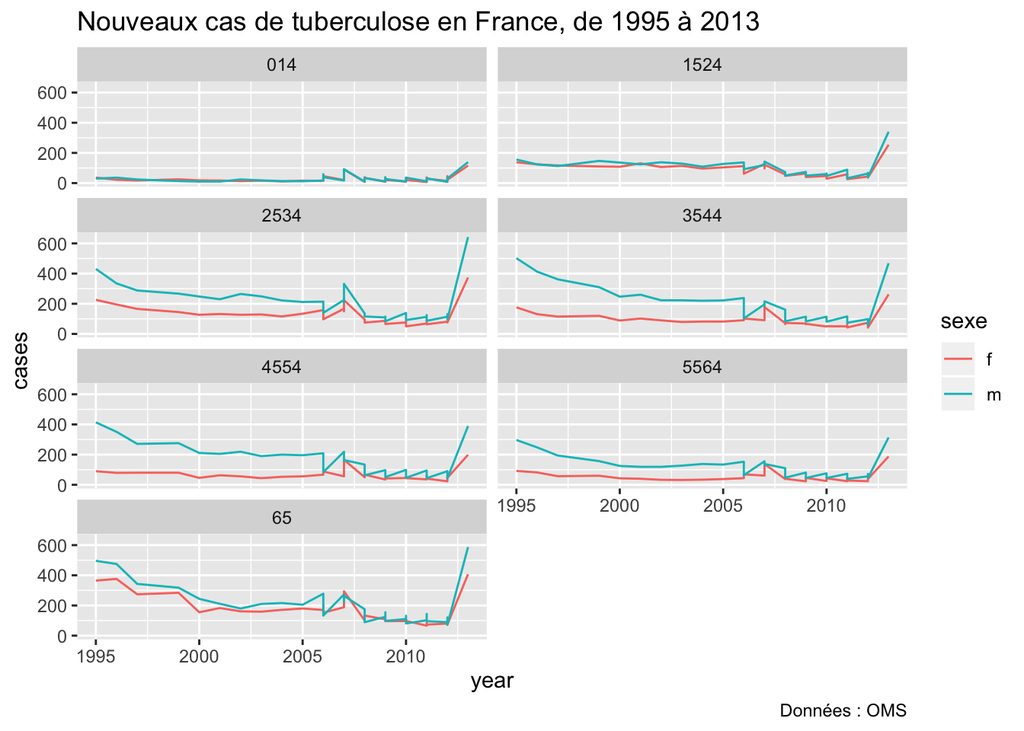

```r
tidyTB %>%
  filter(country == "France") %>%
  ggplot(aes(x = year, y = cases, color = sexe)) +
    geom_line() +
    facet_wrap(~age_class, ncol = 2) +
    labs(title = "Nouveaux cas de tuberculose en France, de 1995 à 2013",
         caption = "Données : OMS")
```

# À la maison : correction chapitre 6

Mise en mémoire des packages utiles

```r
library(dplyr)
library(ggplot2)
library(nycflights13)
```

## Exercice 6.4.2

*Dans la section 3.3.1, nous avons utilisé la fonction View et l’application manuelle de filtres pour déterminer combien de vols avaient quitté l’aéroport JFK le 12 février 2013. En utilisant la fonction filter(), créez un objet nommé `JFK_12fev` qui contiendra les données de ces vols. Vérifiez que cet objet contient bien 282 lignes.*

```r
JFK_12fev <- flights %>%
  filter(origin == "JFK",
         month == 2,
         day == 12)

JFK_12fev
```

```
## # A tibble: 282 x 19
##     year month   day dep_time sched_dep_time dep_delay arr_time
##    <int> <int> <int>    <int>          <int>     <dbl>    <int>
##  1  2013     2    12       17           2245        92      122
##  2  2013     2    12      535            540        -5      950
##  3  2013     2    12      539            540        -1      828
##  4  2013     2    12      555            600        -5      903
##  5  2013     2    12      555            600        -5      858
##  6  2013     2    12      556            600        -4      854
##  7  2013     2    12      601            601         0      911
##  8  2013     2    12      604            600         4      731
##  9  2013     2    12      608            610        -2      905
## 10  2013     2    12      610            615        -5      859
## # … with 272 more rows, and 12 more variables: sched_arr_time <int>,
## #   arr_delay <dbl>, carrier <chr>, flight <int>, tailnum <chr>,
## #   origin <chr>, dest <chr>, air_time <dbl>, distance <dbl>, hour <dbl>,
## #   minute <dbl>, time_hour <dttm>
```

```r
nrow(JFK_12fev)
```

```
## [1] 282
```

## Exercice 6.4.3

*Selon vous, quelles raisons peuvent expliquer qu’un vol qui a décollé n’ait pas d’heure d’atterrissage ?*

Le vol s’est écrasé ? Plus vraisemblablement, le vol a dû faire demi-tour ou être dérouté suite à un problème technique (ou météo ?).

## Exercice 6.5.6

*1. Faites un tableau indiquant combien de vols ont été annulés après le décollage, pour chaque compagnie aérienne.*

```r
flights %>%                     # On prend flights, puis
  filter(!is.na(dep_time),      # On filtre les vols ayant une heure de décollage
         is.na(arr_time)) %>%   # Mais pas d'heure d'arrivée, puis
  group_by(carrier) %>%         # On groupe par compagnie aérienne, puis
  summarize(cancelled = n())    # On compte le nombre de lignes par groupe
```

```
## # A tibble: 13 x 2
##    carrier cancelled
##    <chr>       <int>
##  1 9E             71
##  2 AA             34
##  3 B6             32
##  4 DL             15
##  5 EV            105
##  6 F9              1
##  7 FL              6
##  8 MQ             87
##  9 UA             63
## 10 US             31
## 11 VX              4
## 12 WN              8
## 13 YV              1
```

*2. Faites un tableau indiquant les vitesses de vents minimales, maximales et moyennes, enregistrées chaque mois dans chaque aéroport de New York.*

```r
weather %>%
  group_by(origin, month) %>%
  summarize(max_wind = max(wind_speed, na.rm = TRUE),
            min_wind = min(wind_speed, na.rm = TRUE),
            moy_wind = mean(wind_speed, na.rm = TRUE))
```

```
## # A tibble: 36 x 5
##    origin month max_wind min_wind moy_wind
##    <chr>  <dbl>    <dbl>    <dbl>    <dbl>
##  1 EWR        1     42.6        0     9.87
##  2 EWR        2   1048.         0    12.2
##  3 EWR        3     29.9        0    11.6
##  4 EWR        4     25.3        0     9.63
##  5 EWR        5     33.4        0     8.49
##  6 EWR        6     34.5        0     9.55
##  7 EWR        7     20.7        0     9.15
##  8 EWR        8     21.9        0     7.62
##  9 EWR        9     23.0        0     8.03
## 10 EWR       10     26.5        0     8.32
## # … with 26 more rows
```

*3. Sachant que les vitesses du vent sont exprimées en miles par heure, certaines valeurs sont-elles surprenantes ? À l’aide de la fonction `filter()`, éliminez la ou les valeurs aberrantes.*

Une valeur de plus de 1000 mph est impossible. Il s’agit vraisemblablement d’une erreur de saisie ou d’enregistrement.

```r
weather %>%
  filter(wind_speed <= 500) %>%
  group_by(origin, month) %>%
  summarise(max_wind = max(wind_speed, na.rm = TRUE),
            min_wind = min(wind_speed, na.rm = TRUE),
            moy_wind = mean(wind_speed, na.rm = TRUE))
```

```
## # A tibble: 36 x 5
##    origin month max_wind min_wind moy_wind
##    <chr>  <dbl>    <dbl>    <dbl>    <dbl>
##  1 EWR        1     42.6        0     9.87
##  2 EWR        2     31.1        0    10.7
##  3 EWR        3     29.9        0    11.6
##  4 EWR        4     25.3        0     9.63
##  5 EWR        5     33.4        0     8.49
##  6 EWR        6     34.5        0     9.55
##  7 EWR        7     20.7        0     9.15
##  8 EWR        8     21.9        0     7.62
##  9 EWR        9     23.0        0     8.03
## 10 EWR       10     26.5        0     8.32
## # … with 26 more rows
```

*4. En utilisant les données de vitesse de vent du tableau `weather`, produisez le graphique suivant.*

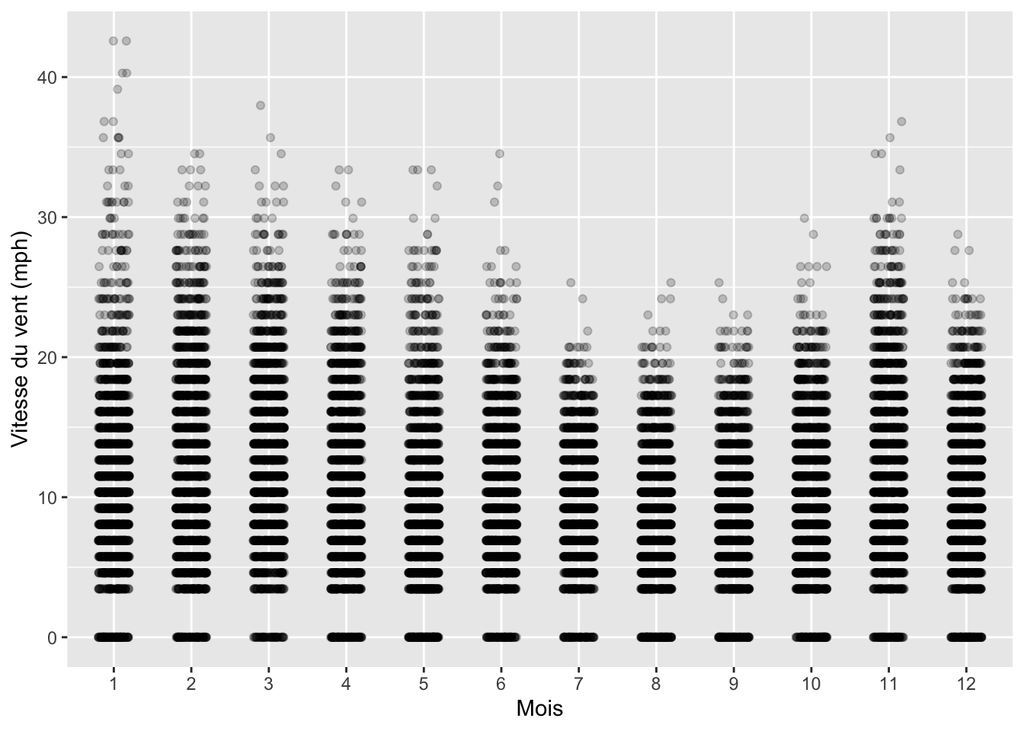

```r
weather %>%
  filter(wind_speed < 500) %>%
  ggplot(aes(x = factor(month), y = wind_speed)) +
  geom_jitter(width = 0.2, height = 0, alpha = 0.2) +
  labs(x = "Mois",
       y = "Vitesse du vent (mph)")
```

*Selon vous, pourquoi les points sont-ils organisés en bandes horizontales ?* *Selon vous, pourquoi n’y a t’il jamais de vent entre 0 et environ 3 miles à l’heure (mph) ?*

L’appareil de mesures n’enregistre que des vitesses de vent par incrément fixe et son seuil de détection est supérieur à des vitesses de 3mph. Cela explique les bandes et le trou entre 0 et 3 mph.

*Sachant qu’en divisant des mph par 1.151 on obtient des vitesses en nœuds, que nous apprend cette commande :*

```r
sort(unique(weather$wind_speed))/1.151
```

```
##  [1]   0.000000   2.999427   3.999235   4.999044   5.998853   6.998662
##  [7]   7.998471   8.998280   9.998089  10.997897  11.997706  12.997515
## [13]  13.997324  14.997133  15.996942  16.996751  17.996560  18.996368
## [19]  19.996177  20.995986  21.995795  22.995604  23.995413  24.995222
## [25]  25.995030  26.994839  27.994648  28.994457  29.994266  30.994075
## [31]  31.993884  32.993692  33.993501  34.993310  36.992928 910.825873
```

Ici, on convertit les données de vitesse de vent de mph en nœuds. La fonction `unique()` permet d’éliminer les duplicats et `sort()` trie les données en ordre croissant. On voit donc que seules quelques valeurs de vent sont enregistrées. L’enregistreur est inacpable de détecter moins de 3 nœuds de vent, et ensuite, il enregistre des valeurs entières (3, 4, 5, et ainsi de suite jusqu’au maximum de 37 nœuds).

## Exercice 6.7.2

*1. Dans `ggplot2` le jeu de données `mpg` contient des informations sur 234 modèles de voitures. Examinez ce jeu de données avec la fonction `View()` et consultez l’aide de ce jeu de données pour savoir à quoi correspondent les différentes variables. Quelle(s) variable(s) nous renseignent sur la consommation des véhicules ? À quoi correspond la variable `disp` ?*

Les variables `hwy` et `cty` nous renseignent sur la consommation des véhicules sur autoroute et en ville respectivement. Les consommations sont données en miles per galon. `disp` est la cylindrée du moteur, son volume en litres.

*2. La consommation est donnée en miles par gallon. Créez une nouvelle variable `conso` qui contiendra la consommation exprimée en nombre de litres pour 100 kilomètres.*

```r
mpg %>%
  mutate(conso = 235.215 / hwy)
```

```
## # A tibble: 234 x 12
##    manufacturer model displ  year   cyl trans drv     cty   hwy fl    class
##    <chr>        <chr> <dbl> <int> <int> <chr> <chr> <int> <int> <chr> <chr>
##  1 audi         a4      1.8  1999     4 auto… f        18    29 p     comp…
##  2 audi         a4      1.8  1999     4 manu… f        21    29 p     comp…
##  3 audi         a4      2    2008     4 manu… f        20    31 p     comp…
##  4 audi         a4      2    2008     4 auto… f        21    30 p     comp…
##  5 audi         a4      2.8  1999     6 auto… f        16    26 p     comp…
##  6 audi         a4      2.8  1999     6 manu… f        18    26 p     comp…
##  7 audi         a4      3.1  2008     6 auto… f        18    27 p     comp…
##  8 audi         a4 q…   1.8  1999     4 manu… 4        18    26 p     comp…
##  9 audi         a4 q…   1.8  1999     4 auto… 4        16    25 p     comp…
## 10 audi         a4 q…   2    2008     4 manu… 4        20    28 p     comp…
## # … with 224 more rows, and 1 more variable: conso <dbl>
```

*3. Faîtes un graphique présentant la relation entre la cylindrée en litres et la consommation sur autoroute exprimée en nombre de litres pour 100 kilomètres. Vous excluerez les véhicules dont la `class`e est `2seater` de ce graphique (il s’agit de voitures de sports très compactes qu’il est difficile de mesurer aux autres). Sur votre graphique, la couleur devrait représenter le type de véhicule. Vous ajouterez une droite de régression en utilisant `geom_smooth(method = "lm")`.*

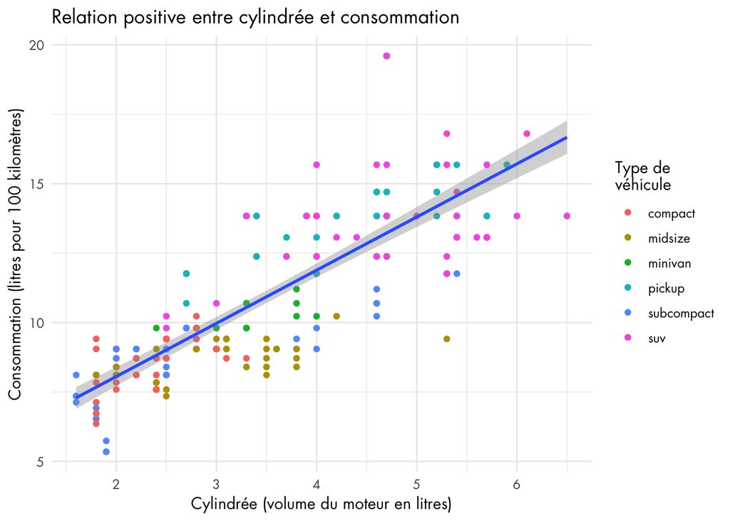

```r
mpg %>%
  filter(class != "2seater") %>%
  mutate(conso = 235.215 / hwy) %>%
  ggplot(aes(x = displ, y = conso)) +
  geom_point(aes(color = class)) +
  geom_smooth(method = "lm") +
  labs(x = "Cylindrée (volume du moteur en litres)",
       y = "Consommation (litres pour 100 kilomètres)",
       color = "Type de\nvéhicule",
       title = "Relation positive entre cylindrée et consommation") +
  theme_minimal(base_family = "Futura LT Book")
```

*4. Ce graphique présente-t’il correctement l’ensemble des données de ces 2 variables ? Pourquoi ? Comparez le graphique de la question 3 ci-dessus et le graphique présenté ci-dessous. Selon vous, quels arguments et/ou fonctions ont été modifiés pour arriver à ce nouveau graphique ? Quels sont les avantages et les inconvénients de ce graphique par rapport au précédent ?

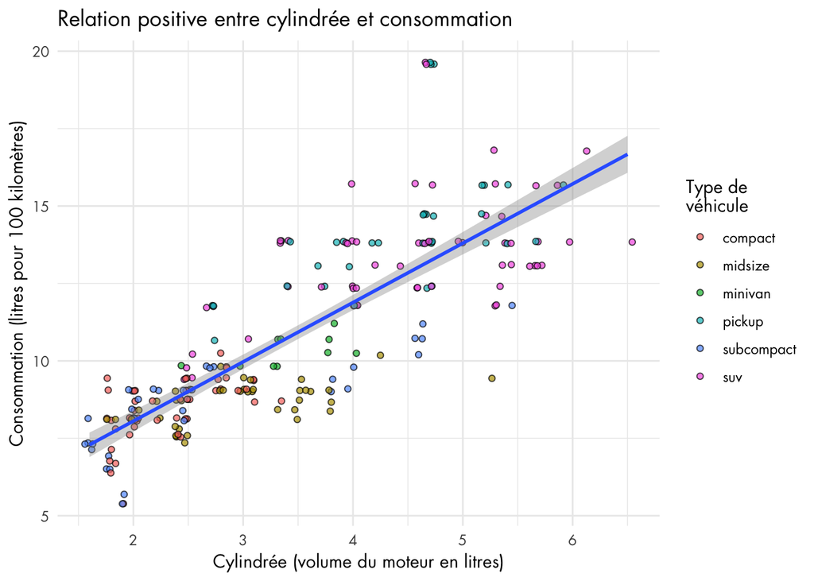

```r
mpg %>%
  filter(class != "2seater") %>%
  mutate(conso = 235.215 / hwy) %>%
  ggplot(aes(x = displ, y = conso)) +
  geom_jitter(aes(fill = class), shape = 21, width = 0.05, height = 0.05, alpha = 0.7) +
  geom_smooth(method = "lm") +
  labs(x = "Cylindrée (volume du moteur en litres)",
       y = "Consommation (litres pour 100 kilomètres)",
       fill = "Type de\nvéhicule",
       title = "Relation positive entre cylindrée et consommation") +
  theme_minimal(base_family = "Futura LT Book")
```

On utilise `geom_jitter()` au lieu de `geom_point()` pour que les points ne se supperposent plus. On voit donc mieux les données. Néanmoins, les points sont légèrement déplacés, ce graphique est donc moins précis que le premier. Il est plus inexact.

Les symboles ont aussi été changés : on est passé à des points avec contour (`shape = 21`) auquels on a attribué une transparence (toujours pour mieux visualiser les chevauchements de points). Du coup, ce n’est plus la `color` qui est associée à la classe de véhicule, mais `fill`, la couleur de remplissage.

## Exercice 6.10

*1. Créez un tableau `delayed` indiquant, pour chaque compagnie aérienne et chaque mois de l’année, le nombre de vols ayant eu un retard supérieur à 30 minutes à l’arrivée à destination. Ce tableau devrait contenir uniquement 3 colonnes :*

- `carrier` : la compagnie aérienne
- `month` : le mois de l’année 2013
- `n_delayed` : le nombre de vols ayant plus de 30 minutes de retard

```r
# Calcul du nombre de vols en retard (+ de 30 min à l'arrivée) pour chaque compagnie et chaque mois
delayed <- flights %>%
  filter(arr_delay > 30) %>%
  group_by(carrier, month) %>%
  summarize(n_delayed = n()) %>%
  select(carrier, month, n_delayed)

delayed
```

```
## # A tibble: 181 x 3
##    carrier month n_delayed
##    <chr>   <int>     <int>
##  1 9E          1       255
##  2 9E          2       237
##  3 9E          3       218
##  4 9E          4       221
##  5 9E          5       317
##  6 9E          6       373
##  7 9E          7       406
##  8 9E          8       246
##  9 9E          9       125
## 10 9E         10       192
## # … with 171 more rows
```

*2. Créez un tableau `total` indiquant le nombre total de vols affrétés (et non annulés) par chaque compagnie aérienne et chaque mois de l’année. Ce tableau devrait contenir seulement 3 colonnes :*

- `carrier` : la compagnie aérienne
- `month` : le mois de l’année 2013
- `n_total` : le nombre total de vols arrivés à destination

```r
# Calcul du nombre total de vols non annulés pour chaque compagnie et chaque mois
total <- flights %>%
  filter(!is.na(arr_delay)) %>%
  group_by(carrier, month) %>%
  summarize(n_total = n())

total
```

```
## # A tibble: 185 x 3
##    carrier month n_total
##    <chr>   <int>   <int>
##  1 9E          1    1480
##  2 9E          2    1341
##  3 9E          3    1510
##  4 9E          4    1399
##  5 9E          5    1383
##  6 9E          6    1260
##  7 9E          7    1339
##  8 9E          8    1373
##  9 9E          9    1468
## 10 9E         10    1635
## # … with 175 more rows
```

*3. Fusionnez ces 2 tableaux en réalisant la jointure appropriée. Le tableau final, que vous nommerez `carrier_stats` devrait contenir 185 lignes. Si certaines colonnes contiennent des données manquantes, remplacez-les par des 0 à l’aide des fonctions `mutate()` et `na_replace()`.*

*4. Ajoutez à votre tableau `carrier_stats` une variable `rate` qui contient la proportion de vols arrivés à destination avec plus de 30 minutes de retard, pour chaque compagnie aérienne et chaque mois de l’année.*

*5. Ajoutez à votre tableau `carrier_stats` le nom complet des compagnies aériennes en réalisant la jointure appropriée avec le tableau `airlines`.*

```r
# Création du tableau de synthèse (2 left_join())
carrier_stats <- total %>%
  left_join(delayed) %>%
  mutate(n_delayed = replace_na(n_delayed, 0),
         rate = n_delayed / n_total) %>%
  left_join(airlines)
carrier_stats
```

```
## # A tibble: 185 x 6
##    carrier month n_total n_delayed   rate name
##    <chr>   <int>   <int>     <dbl>  <dbl> <chr>
##  1 9E          1    1480       255 0.172  Endeavor Air Inc.
##  2 9E          2    1341       237 0.177  Endeavor Air Inc.
##  3 9E          3    1510       218 0.144  Endeavor Air Inc.
##  4 9E          4    1399       221 0.158  Endeavor Air Inc.
##  5 9E          5    1383       317 0.229  Endeavor Air Inc.
##  6 9E          6    1260       373 0.296  Endeavor Air Inc.
##  7 9E          7    1339       406 0.303  Endeavor Air Inc.
##  8 9E          8    1373       246 0.179  Endeavor Air Inc.
##  9 9E          9    1468       125 0.0851 Endeavor Air Inc.
## 10 9E         10    1635       192 0.117  Endeavor Air Inc.
## # … with 175 more rows
```

*6. Faites un graphique synthétique présentant ces résultats de la façon la plus claire possible*

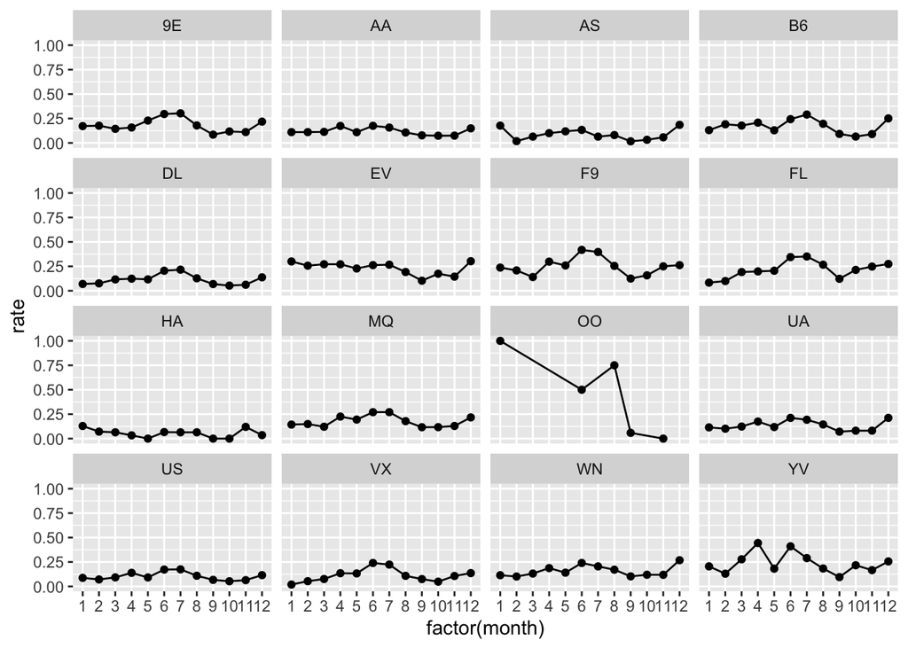

```r
# Création de graphiques de synthèse
carrier_stats %>%
  ggplot(aes(x = factor(month), y = rate, group = 1)) +
  geom_line() +
  geom_point() +
  facet_wrap(~carrier, ncol=4)
```

*7. Quelle compagnie aérienne semble se comporter très différemment des autres ? À quoi pouvez-vous attribuer ce comportement atypique ?*

La compagnie `OO` (SkyWest Airlines Inc.) a un comportement très atypique dû au très faible nombre de vols affrétés (1 seul en janvier, 2 en juin, 4 en août, 17 en septembre et 5 en novembre). Elle n’est d’ailleurs présente que quelques mois de l’année dans les aéroports de New York

```r
carrier_stats %>%
  filter(carrier == "OO")
```

```
## # A tibble: 5 x 6
##   carrier month n_total n_delayed   rate name
##   <chr>   <int>   <int>     <dbl>  <dbl> <chr>
## 1 OO          1       1         1 1      SkyWest Airlines Inc.
## 2 OO          6       2         1 0.5    SkyWest Airlines Inc.
## 3 OO          8       4         3 0.75   SkyWest Airlines Inc.
## 4 OO          9      17         1 0.0588 SkyWest Airlines Inc.
## 5 OO         11       5         0 0      SkyWest Airlines Inc.
```

*8. Pour les compagnies affretant un grand nombre de vols chaque année (e.g. `UA`, `B6` et `EV`), quelles sont les périodes où les plus fortes proportions de vols en retard sont observées ? Et les plus faibles ? Quelle(s) hypothèse(s) pouvez-vous formuler pour expliquer ces observations ?*

Pour les les plus grosses compagnies, les retards les plus fréquents sont observés l’été, et les moins fréquents en automne. Cela correspond aux périodes de très fortes affluences en été, et au moins fortes affluences à la rentrée de septembre. C’est du moins le cas pour `UA` et `B6`. Moins pour `EV`.

```r
carrier_stats %>%
  filter(carrier %in% c("UA", "B6", "EV")) %>%
  select(carrier, month, n_total) %>%
  spread(carrier, n_total)
```

```
## # A tibble: 12 x 4
##    month    B6    EV    UA
##    <int> <int> <int> <int>
##  1     1  4413  3964  4590
##  2     2  3945  3539  4157
##  3     3  4746  4371  4909
##  4     4  4459  4321  4978
##  5     5  4537  4566  4890
##  6     6  4550  4075  4885
##  7     7  4902  4303  4971
##  8     8  4941  4337  5085
##  9     9  4270  4548  4636
## 10    10  4357  4812  5035
## 11    11  4273  4381  4827
## 12    12  4656  3891  4819
```

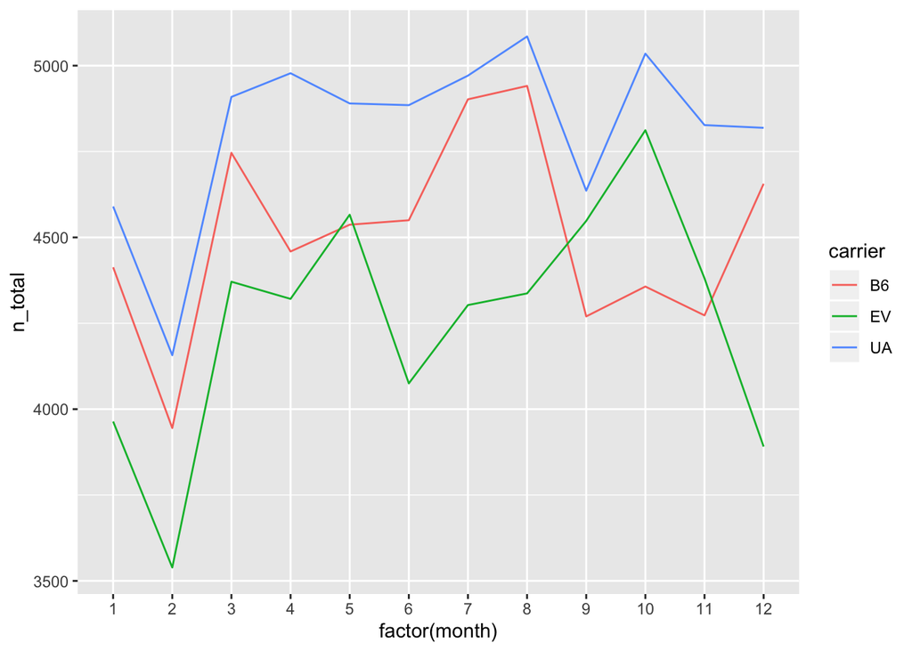

```r
carrier_stats %>%
  filter(carrier %in% c("UA", "B6", "EV")) %>%
  ggplot(aes(x = factor(month), y = n_total, group = carrier, color = carrier)) +
    geom_line()
```

*9. Faites un tableau synthétique présentant ces résultats de la façon la plus compacte et claire que possible, afin par exemple de les intégrer à un rapport.*

```r
# Création du tableau synthétique. Il faut dégrouper le tableau avec ungroup() pour ne pas avoir la variable carrier. J'arrondis aussi à 3 chiffres significatifs.
carrier_stats %>%
  ungroup() %>%
  select(name, month, rate) %>%
  mutate(rate = round(rate, 3)) %>%
  spread(month, rate)
```

```
## # A tibble: 16 x 13
##    name    `1`    `2`    `3`    `4`    `5`   `6`    `7`   `8`   `9`   `10`
##    <chr> <dbl>  <dbl>  <dbl>  <dbl>  <dbl> <dbl>  <dbl> <dbl> <dbl>  <dbl>
##  1 AirT… 0.083  0.099  0.191  0.198  0.205 0.344  0.351 0.267 0.123  0.214
##  2 Alas… 0.177  0.019  0.065  0.1    0.119 0.133  0.065 0.081 0.017  0.032
##  3 Amer… 0.111  0.111  0.113  0.174  0.11  0.175  0.157 0.107 0.078  0.074
##  4 Delt… 0.069  0.076  0.116  0.124  0.117 0.205  0.216 0.127 0.069  0.053
##  5 Ende… 0.172  0.177  0.144  0.158  0.229 0.296  0.303 0.179 0.085  0.117
##  6 Envo… 0.143  0.149  0.121  0.225  0.194 0.27   0.271 0.179 0.117  0.117
##  7 Expr… 0.3    0.257  0.271  0.271  0.228 0.262  0.267 0.192 0.103  0.175
##  8 Fron… 0.237  0.208  0.14   0.298  0.259 0.418  0.397 0.255 0.125  0.158
##  9 Hawa… 0.129  0.071  0.065  0.033  0     0.067  0.065 0.065 0      0
## 10 JetB… 0.131  0.191  0.178  0.208  0.129 0.243  0.290 0.196 0.092  0.065
## 11 Mesa… 0.205  0.13   0.278  0.444  0.182 0.41   0.290 0.183 0.095  0.217
## 12 SkyW… 1     NA     NA     NA     NA     0.5   NA     0.75  0.059 NA
## 13 Sout… 0.115  0.101  0.132  0.188  0.141 0.24   0.205 0.171 0.103  0.119
## 14 Unit… 0.115  0.101  0.123  0.174  0.118 0.212  0.193 0.145 0.071  0.081
## 15 US A… 0.088  0.071  0.092  0.139  0.092 0.173  0.175 0.109 0.067  0.053
## 16 Virg… 0.019  0.054  0.076  0.135  0.133 0.24   0.224 0.108 0.075  0.049
## # … with 2 more variables: `11` <dbl>, `12` <dbl>
```